# Lab 2 - Introduction to Data

202330420212-Sihan Chen & 202364820921-Yue Zhang

2025-04-02

# 1 Introduction

In this lab, we explore real-world baby naming data using the babynames dataset in R. This dataset contains information on baby names registered in the United States from 1880 onward, including the baby’s name, gender, year of birth, and the number of babies given that name.

Our objectives are:

- To load and explore the dataset
- To analyze the popularity trends of a chosen name over time
- To identify top baby names by frequency
- To create rich visualizations comparing trends and gender-based preferences

# 2 Exercise 1 - Load and view dataset

We start by installing and loading the necessary packages: babynames, dplyr, and ggplot2

```r
library(babynames)
library(dplyr)
library(ggplot2)
```

Now we take a quick look at the dataset:

```r
head(babynames)
```

```
## # A tibble: 6 × 5
##    year sex   name          n   prop
##   <dbl> <chr> <chr>     <int>  <dbl>
## 1  1880 F     Mary       7065 0.0724
## 2  1880 F     Anna       2604 0.0267
## 3  1880 F     Emma       2003 0.0205
## 4  1880 F     Elizabeth  1939 0.0199
## 5  1880 F     Minnie     1746 0.0179
## 6  1880 F     Margaret   1578 0.0162
```

```r
str(babynames)
```

```
## tibble [1,924,665 × 5] (S3: tbl_df/tbl/data.frame)
##  $ year: num [1:1924665] 1880 1880 1880 1880 1880 1880 1880 1880 1880 1880 ...
##  $ sex : chr [1:1924665] "F" "F" "F" "F" ...
##  $ name: chr [1:1924665] "Mary" "Anna" "Emma" "Elizabeth" ...
##  $ n   : int [1:1924665] 7065 2604 2003 1939 1746 1578 1472 1414 1320 1288 ...
##  $ prop: num [1:1924665] 0.0724 0.0267 0.0205 0.0199 0.0179 ...
```

```r
summary(babynames)
```

```
##       year          sex                name                 n
##  Min.   :1880   Length:1924665     Length:1924665     Min.   :    5.0
##  1st Qu.:1951   Class :character   Class :character   1st Qu.:    7.0
##  Median :1985   Mode  :character   Mode  :character   Median :   12.0
##  Mean   :1975                                         Mean   :  180.9
##  3rd Qu.:2003                                         3rd Qu.:   32.0
##  Max.   :2017                                         Max.   :99686.0
##       prop
##  Min.   :2.260e-06
##  1st Qu.:3.870e-06
##  Median :7.300e-06
##  Mean   :1.363e-04
##  3rd Qu.:2.288e-05
##  Max.   :8.155e-02
```

```r
range(babynames$year)
```

```
## [1] 1880 2017
```

```r
length(unique(babynames$name))
```

```
## [1] 97310
```

# 3 Exercise 2 - Select a name

Let us choose the name “Emma” for our analysis. We will examine how its popularity has changed over the years.

```r
emma <- babynames %>%
  filter(name == "Emma")

head(emma)
```

```
## # A tibble: 6 × 5
##    year sex   name      n      prop
##   <dbl> <chr> <chr> <int>     <dbl>
## 1  1880 F     Emma   2003 0.0205
## 2  1880 M     Emma     10 0.0000845
## 3  1881 F     Emma   2034 0.0206
## 4  1881 M     Emma      9 0.0000831
## 5  1882 F     Emma   2303 0.0199
## 6  1882 M     Emma      7 0.0000574
```

# 4 Exercise 3 - Plot trend of the name

We now plot the number of babies named “Emma” over time, separated by gender.

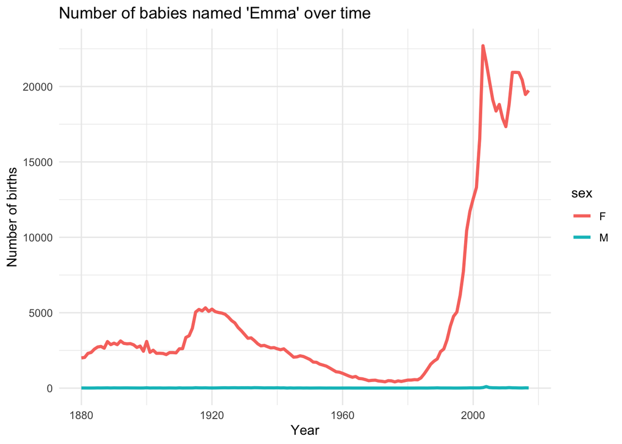

```r
ggplot(emma, aes(x = year, y = n, color = sex)) +
  geom_line(size = 1.2) +
  labs(
    title = "Number of babies named 'Emma' over time",
    x = "Year",
    y = "Number of births"
  ) +
  theme_minimal()
```

Observation: The name Emma saw a dramatic rise in popularity in the early 2000s, especially among girls.

# 5 Exercise 4 - Top 5 Names in Recent Years

We now determine the most popular names in the last decade (2010 to 2020), based on total number of babies given each name.

```r
top_names_2010s <- babynames %>%
  filter(year >= 2010 & year <= 2020) %>%
  group_by(name) %>%
  summarise(total_babies = sum(n)) %>%
  arrange(desc(total_babies)) %>%
  slice_head(n = 5)

top_names_2010s
```

```
## # A tibble: 5 × 2
##   name     total_babies
##   <chr>           <int>
## 1 Emma           158715
## 2 Sophia         153095
## 3 Olivia         147630
## 4 Noah           146059
## 5 Isabella       142221
```

To visualize the Top 5 Names in the 2010s:

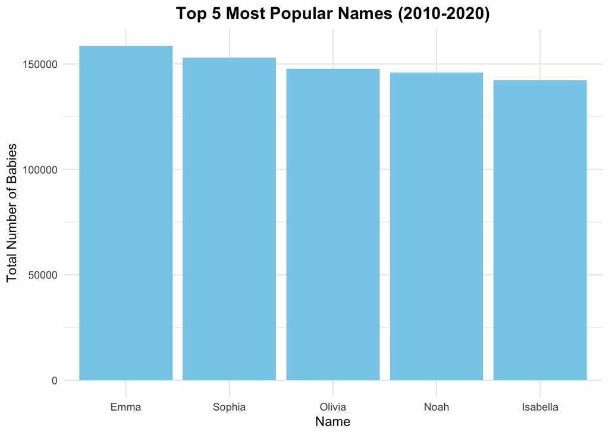

```r
ggplot(top_names_2010s, aes(x = reorder(name, -total_babies), y = total_babies)) +
  geom_bar(stat = "identity", fill = "skyblue") +
  labs(
    title = "Top 5 Most Popular Names (2010-2020)",
    x = "Name",
    y = "Total Number of Babies"
  ) +
  theme_minimal() +
  theme(
    plot.title = element_text(size = 14, face = "bold", hjust = 0.5)
  )
```

# 6 Exercise 5 - Gender comparison for a specific year

We now look at the top 5 male and top 5 female names in 2017.

```r
top2017 <- babynames %>%
  filter(year == 2017) %>%
  group_by(sex, name) %>%
  summarise(total = sum(n), .groups = "drop") %>%
  arrange(sex, desc(total)) %>%
  group_by(sex) %>%
  slice_head(n = 5) %>%
  ungroup()
top2017  # check the data
```

```
## # A tibble: 10 × 3
##    sex   name     total
##    <chr> <chr>    <int>
##  1 F     Emma     19738
##  2 F     Olivia   18632
##  3 F     Ava      15902
##  4 F     Isabella 15100
##  5 F     Sophia   14831
##  6 M     Liam     18728
##  7 M     Noah     18326
##  8 M     William  14904
##  9 M     James    14232
## 10 M     Logan    13974
```

To visualize Gender-Based Popular Names in 2017:

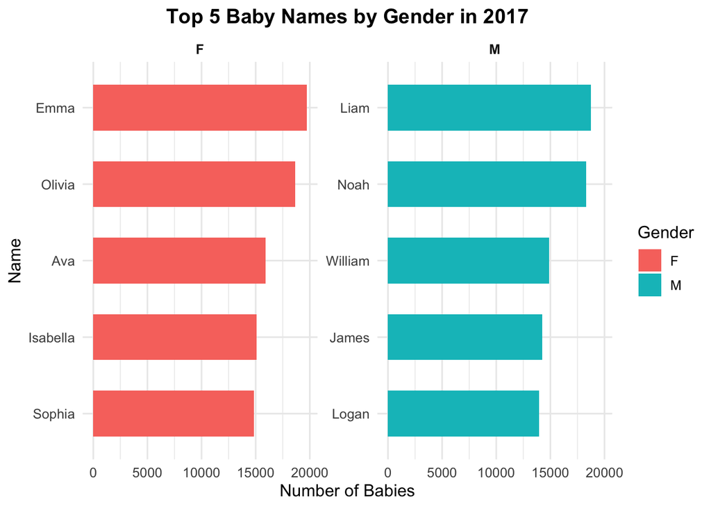

```r
ggplot(top2017, aes(x = reorder(name, total), y = total, fill = sex)) +
  geom_col(show.legend = TRUE, width = 0.6) +
  facet_wrap(~ sex, scales = "free_y") +
  coord_flip() +
  labs(
    title = "Top 5 Baby Names by Gender in 2017",
    x = "Name",
    y = "Number of Babies",
    fill = "Gender"
  ) +
  theme_minimal(base_size = 12) +
  theme(
    plot.title = element_text(hjust = 0.5, face = "bold"),
    strip.text = element_text(face = "bold")
  )
```

Observation: In 2017, the top baby names for both genders reveal distinct naming preferences. For girls, Emma, Olivia, and Ava led the list, reflecting a continued popularity of short, soft-sounding names with vowel endings. For boys, names like Liam, Noah, and William dominated, which are traditional and timeless choices. The difference in trends suggests that while female names tend to evolve with contemporary preferences, male names often maintain a more classic and stable pattern.

# 7 Conclusion

In this lab, we successfully:

- Explored a real-world dataset using `babynames`, Applied data wrangling techniques with `dplyr`, Used `ggplot2` for high-quality data visualizations
- Investigated long-term trends for a given name
- Identified top baby names by total count
- Compared gender-based naming trends for a given year

This foundational analysis sets the stage for more complex exploratory and predictive modeling in future labs.